# Lab 3a - Basic network plotting

Douglas Luke

July 27, 2021

## Introduction

This lab corresponds to Chapter 4 - Basic Network Plotting and Layout.

```r
library(statnet)
library(UserNetR)
data(Moreno)
```

## Basic network plotting

### Plotting internally vs. to an external file

If a basic plot command is contained in an R-code chunk, then the plot will be directed to the notebook or to the plots tab in the RStudio interface.

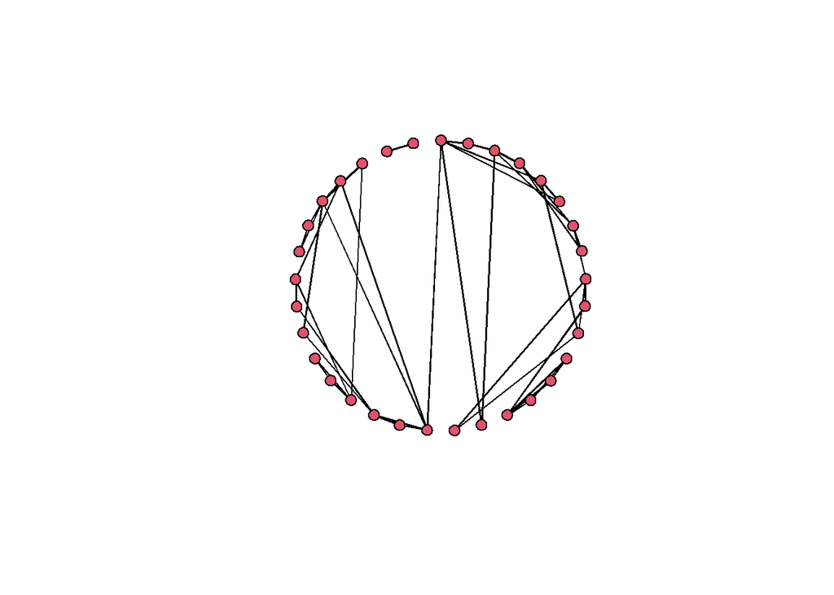

```r
plot(Moreno,mode="circle",vertex.cex=1.5)
```

Depending on the size of your computer monitor, size of RStudio windows, etc., the network graphic may not look as good as it could. For any final version graphic, it is a good idea to print the graphic to an external file. R handles this by printing to a plot ‘device.’

```r
pdf("test1.pdf",width=11,height=8.5)
plot(Moreno,mode="circle",vertex.cex=1.5,main="Does This Look Good?")
```

The built-in cairographics plot device produces high quality PDF, SVG, and postscript graphics files.

E: Learn more about plot devices by seeing the help for `Devices`, `cairo_pdf` and `dev.print`.

### Different layout options

Two things to note here. First, a layout option can be specified in the call to the plot function. Second, note how we are using the `par()` function to prespecify some overall graphics properties, in this case we are reducing the size of the figure margins (`mar`) and setting up a graphics window that will accept two plots, arranged in 1 row and 2 columns (`mfrow=c(1,2)`).

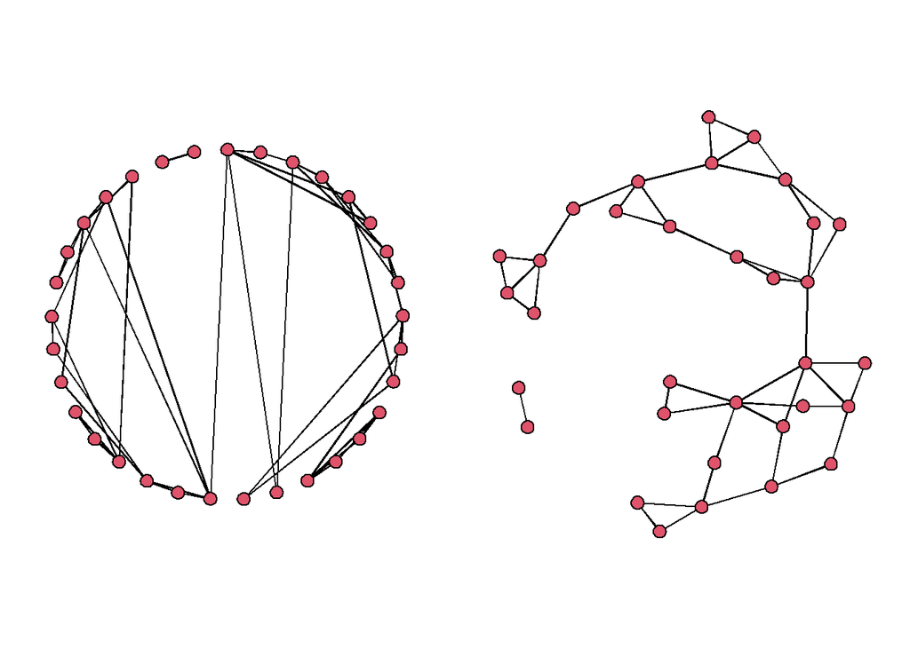

```r
op <- par(mar = rep(0, 4),mfrow=c(1,2))
plot(Moreno,mode="circle",vertex.cex=1.5)
plot(Moreno,mode="fruchtermanreingold",vertex.cex=1.5)
```

```r
par(op)
```

The `par(op)` command resets the graphics options to what we had before. A little hard to follow the logic, but the above code structure should always be used.

Q: What is the default layout option, if one is not specified?

E: How could you arrange the plots vertically, instead of horizontally?

### Exploring layouts

Review material in book about meaningful and non-meaningful information in network graphics.

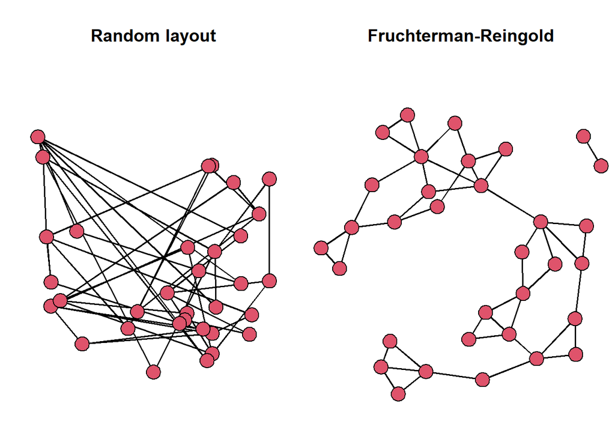

```r
op <- par(mar = c(0,0,4,0),mfrow=c(1,2))
gplot(Moreno,gmode="graph",mode="random",
      vertex.cex=1.5,main="Random layout")
gplot(Moreno,gmode="graph",mode="fruchtermanreingold",
      vertex.cex=1.5,main="Fruchterman-Reingold")
```

```r
par(op)
```

Q: Why is the second option above more informative?

Q: Why do you get different layouts each time you run the code? Is the 2nd option always better?

Looking at some more layout options. Notice that `gplot` has more layout options than `plot`.

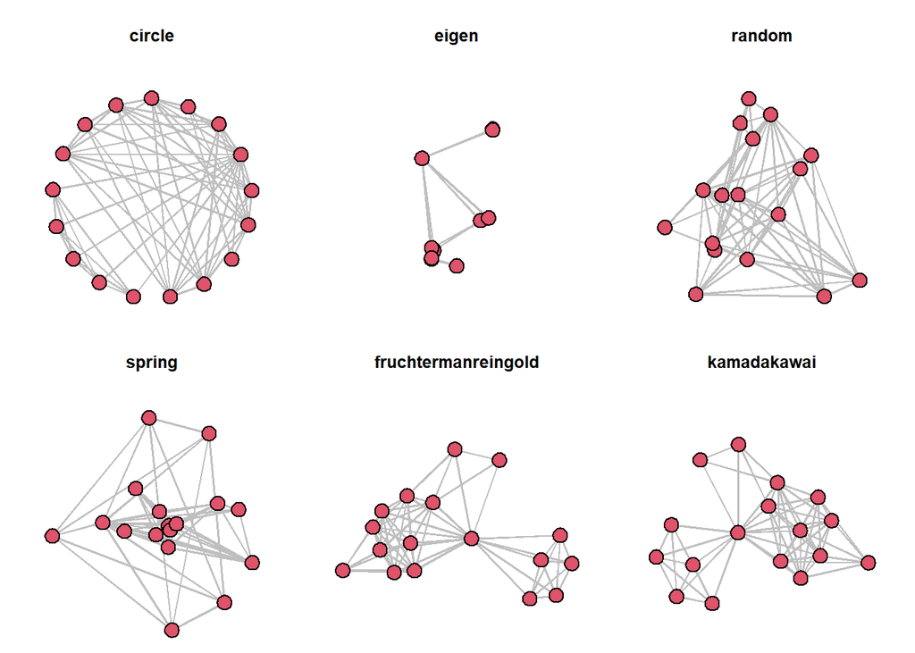

```r
data(Bali)
op <- par(mar=c(0,0,4,0),mfrow=c(2,3))
gplot(Bali,gmode="graph",edge.col="grey75",
      vertex.cex=1.5,mode='circle',main="circle")
gplot(Bali,gmode="graph",edge.col="grey75",
      vertex.cex=1.5,mode='eigen',main="eigen")
gplot(Bali,gmode="graph",edge.col="grey75",
      vertex.cex=1.5,mode='random',main="random")
gplot(Bali,gmode="graph",edge.col="grey75",
      vertex.cex=1.5,mode='spring',main="spring")
gplot(Bali,gmode="graph",edge.col="grey75",
      vertex.cex=1.5,mode='fruchtermanreingold',
      main='fruchtermanreingold')
gplot(Bali,gmode="graph",edge.col="grey75",
      vertex.cex=1.5,mode='kamadakawai',
      main='kamadakawai')
```

```r
par(op)
```

E: Try out other layout functions, after looking at `?gplot.layout()`.